# Exercice d'introduction sur le framework BI

Répondez aux questions, en réfléchissant à la réponse par groupe de 3-4 personnes. (Tout le monde participe à toutes les questions/réponses.)

## Questions

```python
import pandas as pd

data = pd.read_csv('data/information.csv')
data.head(10)
```

|  | row_id | day | employee_code | cost_day | sales_day |
| --- | --- | --- | --- | --- | --- |
| 0 | 0 | 0 | A | 100 | 80 |
| 1 | 1 | 0 | B | 180 | 220 |
| 2 | 2 | 1 | B | 100 | 100 |
| 3 | 3 | 1 | D | 100 | 120 |
| 4 | 4 | 3 | B | 160 | 220 |
| 5 | 5 | 3 | E | 180 | 160 |
| 6 | 6 | 3 | F | 120 | 140 |
| 7 | 7 | 4 | A | 100 | 240 |
| 8 | 8 | 4 | B | 140 | 120 |
| 9 | 9 | 4 | E | 120 | 220 |

**Q1) En présentant uniquement ce tableau-ci, est-il facile de prendre une décision et/ou tirer des conclusions ?**

Par exemple :

- Qui sont les (moins) bons employés en termes de cout-vente ?
- Quel est l'évolution des ventes ?

Réfléchissez-y entre vous.

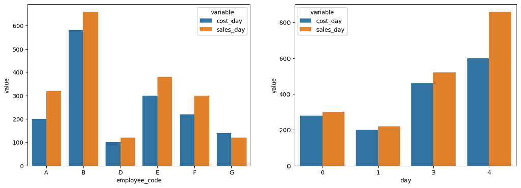

```python
import matplotlib.pyplot as plt
import seaborn as sns

gb1 = data.groupby('employee_code').agg({'cost_day':'sum','sales_day':'sum'}).reset_index().melt('employee_code')
#display(gb1)


plt.figure(figsize=(15,5))

plt.subplot(1,2,1)
sns.barplot(data=gb1, x= 'employee_code',y='value',hue='variable')

gb3 = data.groupby('day').agg({'cost_day':'sum','sales_day':'sum'}).reset_index().melt('day')
#display(gb3)

plt.subplot(1,2,2)
sns.barplot(data=gb3, x = 'day', y = 'value', hue='variable')

plt.show()
```

**R1) On va évidemment au moins essayer de résumer le tableau avec un autre tableau ou via (un ensemble) de graphiques**

**Contexte Q2:** Il faut savoir que les serveurs opérationnels sont (parfois) sollicités **toutes les minutes**, afin de faire fonctionner des applications orientées clients (=les clients utilisent nos services).

Malheureusement, quand on veut récupérer les données sur ces serveurs-là, on **interrompt** les connexions avec les app client à ce moment-là. Cette interruption peut prendre plus que 1 heure, ce qui peut faire fuir les clients.

**Q2) De quelle manière peut-on avoir les graphiques sans interrompre les serveurs opérationnels ?**

**R2.1) Il faut interrompre les serveurs opérationnels au moment où ils sont le moins sollicités par les clients : la nuit.** Mais, en général, il n'y a pas d'employé pour faire les graphiques à ce moment. **R2.2) Il faut planifier la requête des données et les stocker pour le lendemain : avoir un serveur qui copie les infos nécessaires = un serveur analytique**

**Q3) Devons-nous faire une copie exacte (données et schéma) des données opérationnelles ?**

**R3) On veut garder les données pertinentes (parfois tout), mais cela ne signifie pas qu'on doit garder les mêmes tables, ni le même schéma de relation des tables : on peut essayer de le simplifier et/ou de le restructurer.**

Les serveurs opérationnels sont optimisés pour la lecture et l'écriture de quelques lignes à la fois : ceci est possible, car le modèle relationnel est construit pour qu'il y ait le moins de redondance possible de données parmi les tables de ce modèle relationnel (opérationnel).

Les serveurs analytiques ne sont pas soumis aux mêmes contraintes que les serveurs opérationnels:

- Très peu de personnes vont interagir avec ceux-ci.
- De plus, pour faire des graphiques (et des agrégations), il est nécessaire de récupérer une grande quantité de données (=pas 3-4 lignes).

=> il faut optimiser un serveur analytique pour :

- les requêtes de données (=moins de jointure)
- les personnes qui vont faire les requêtes de données (=navigation simplifiée).

Q4) On a deux ou plusieurs sources de données (imaginons 2 serveurs SQL, 1 fichier Excel, ceux-ci pourraient correspondre aux 'département ventes','département production','ressources humaines') ;  
Peut-on mélanger les (copies de) données ou doit-on garder les (copies de) données séparées ?

**R4) On va centraliser les données afin de croiser les informations des différentes sources : cela permet de faire une analyse plus poussée**

**Q5) OK, on va tout centraliser (mettre dans 1 serveur SQL), mais comment fait-on pour croiser des données des tables d'une source avec les données de tables d'une autre source ?**